# Data Science Fall 2014 R Project

**This project analyzes the Diamonds data from the ggplot2 package which has been supplemented with additional synthetic data and stored in an Oracle database.**

```r
# To get this to work in your environment, change the following directory/folder path to the path to your project files.
setwd("~/Desktop/DataScienceFall2014/RProject")
system("cat .Rprofile", intern = TRUE)
```

```
## character(0)
## attr(,"status")
## [1] 1
```

### Diamonds Data Model

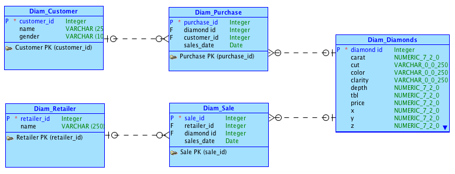

### Diamonds Data

#### Diamonds.ddl

```r
# To get this to work in your environment, change the following directory/folder path to the path to your project files.
setwd("~/Desktop/DataScienceFall2014/RProject/02DiamondsData")
system("cat Diamonds.ddl", intern = TRUE)
```

```
##  [1] "DROP TABLE Diamonds;"
##  [2] ""
##  [3] "CREATE TABLE Diamonds ("
##  [4] "   \"diamond_id\" NUMBER(7,2) NOT NULL,"
##  [5] "   \"carat\" NUMBER(7,2),"
##  [6] "   \"cut\" VARCHAR2(250),"
##  [7] "   \"color\" VARCHAR2(250),"
##  [8] "   \"clarity\" VARCHAR2(250),"
##  [9] "   \"depth\" NUMBER(7,2),"
## [10] "   \"tbl\" NUMBER(7,2),"
## [11] "   \"price\" NUMBER(7,2),"
## [12] "   \"x\" NUMBER(7,2),"
## [13] "   \"y\" NUMBER(7,2),"
## [14] "   \"z\" NUMBER(7,2)"
## [15] ");"
## [16] "   ALTER TABLE Diamonds ADD CONSTRAINT Diamonds_PK PRIMARY KEY ( \"diamond_id\" ) ;"
```

#### First few rows of Diamonds.dml

```r
# To get this to work in your environment, change the following directory/folder path to the path to your project files.
setwd("~/Desktop/DataScienceFall2014/RProject/02DiamondsData")
system("head Diamonds.dml.head", intern = TRUE)
```

```
##  [1] "insert into diamonds(\"diamond_id\", \"carat\",\"cut\",\"color\",\"clarity\",\"depth\",\"tbl\",\"price\",\"x\",\"y\",\"z\") values(1,0.23,'Ideal','E','SI2',61.5,55,NULL,3.95,3.98,2.43);"
##  [2] "insert into diamonds(\"diamond_id\", \"carat\",\"cut\",\"color\",\"clarity\",\"depth\",\"tbl\",\"price\",\"x\",\"y\",\"z\") values(2,0.21,'Premium','E','SI1',59.8,61,326,3.89,3.84,2.31);"
##  [3] "insert into diamonds(\"diamond_id\", \"carat\",\"cut\",\"color\",\"clarity\",\"depth\",\"tbl\",\"price\",\"x\",\"y\",\"z\") values(3,0.23,'Good','E','VS1',56.9,65,327,4.05,4.07,2.31);"
##  [4] "insert into diamonds(\"diamond_id\", \"carat\",\"cut\",\"color\",\"clarity\",\"depth\",\"tbl\",\"price\",\"x\",\"y\",\"z\") values(4,0.29,'Premium','I','VS2',62.4,58,334,4.2,4.23,2.63);"
##  [5] "insert into diamonds(\"diamond_id\", \"carat\",\"cut\",\"color\",\"clarity\",\"depth\",\"tbl\",\"price\",\"x\",\"y\",\"z\") values(5,0.31,'Good','J','SI2',63.3,58,335,4.34,4.35,2.75);"
##  [6] "insert into diamonds(\"diamond_id\", \"carat\",\"cut\",\"color\",\"clarity\",\"depth\",\"tbl\",\"price\",\"x\",\"y\",\"z\") values(6,0.24,'Very Good','J','VVS2',62.8,57,336,3.94,3.96,2.48);"
##  [7] "insert into diamonds(\"diamond_id\", \"carat\",\"cut\",\"color\",\"clarity\",\"depth\",\"tbl\",\"price\",\"x\",\"y\",\"z\") values(7,0.24,'Very Good','I','VVS1',62.3,57,336,3.95,3.98,2.47);"
##  [8] "insert into diamonds(\"diamond_id\", \"carat\",\"cut\",\"color\",\"clarity\",\"depth\",\"tbl\",\"price\",\"x\",\"y\",\"z\") values(8,0.26,'Very Good','H','SI1',61.9,55,337,4.07,4.11,2.53);"
##  [9] "insert into diamonds(\"diamond_id\", \"carat\",\"cut\",\"color\",\"clarity\",\"depth\",\"tbl\",\"price\",\"x\",\"y\",\"z\") values(9,0.22,'Fair','E','VS2',65.1,61,337,3.87,3.78,2.49);"
## [10] "insert into diamonds(\"diamond_id\", \"carat\",\"cut\",\"color\",\"clarity\",\"depth\",\"tbl\",\"price\",\"x\",\"y\",\"z\") values(10,0.23,NULL,'H','VS1',59.4,61,338,4,4.05,2.39);"
```

#### Python script to generate synthetic Diamonds data.

```r
# To get this to work in your environment, change the following
# directory/folder path to the path to your project files.
setwd("~/Desktop/DataScienceFall2014/RProject/02DiamondsData")
# I can't get this to print out properly so I've commented it out for now.
# system('cat fakeDiamondsData.py', intern = TRUE)
```

#### DiamondsRest.ddl

```r
# To get this to work in your environment, change the following directory/folder path to the path to your project files.
setwd("~/Desktop/DataScienceFall2014/RProject/02DiamondsData")
system("cat DiamondsRest.ddl", intern = TRUE)
```

```
##  [1] "DROP TABLE Diam_Customer CASCADE CONSTRAINTS ;"
##  [2] ""
##  [3] "DROP TABLE Diam_Purchase CASCADE CONSTRAINTS ;"
##  [4] ""
##  [5] "DROP TABLE Diam_Retailer CASCADE CONSTRAINTS ;"
##  [6] ""
##  [7] "DROP TABLE Diam_Sale CASCADE CONSTRAINTS ;"
##  [8] ""
##  [9] "CREATE TABLE Diam_Customer"
## [10] "  ("
## [11] "    customer_id INTEGER NOT NULL ,"
## [12] "    name        VARCHAR2 (250) ,"
## [13] "    gender      VARCHAR2 (10)"
## [14] "  ) ;"
## [15] "ALTER TABLE Diam_Customer ADD CONSTRAINT Diam_Customer_PK PRIMARY KEY ( customer_id ) ;"
```

[output cut: 33 more lines]

#### First few rows of fakeDiamondsData.dml

```r
# To get this to work in your environment, change the following directory/folder path to the path to your project files.
setwd("~/Desktop/DataScienceFall2014/RProject/02DiamondsData")
system("head fakeDiamondsData.dml.head", intern = TRUE)
```

```
##  [1] "insert into diam_customer(customer_id, name, gender) values(1, 'Jacob', 'm');"
##  [2] "insert into diam_customer(customer_id, name, gender) values(2, 'Mason', 'm');"
##  [3] "insert into diam_customer(customer_id, name, gender) values(3, 'Ethan', 'm');"
##  [4] "insert into diam_customer(customer_id, name, gender) values(4, 'Noah', 'm');"
##  [5] "insert into diam_customer(customer_id, name, gender) values(5, 'William', 'm');"
##  [6] "insert into diam_customer(customer_id, name, gender) values(6, 'Liam', 'm');"
##  [7] "insert into diam_customer(customer_id, name, gender) values(7, 'Jayden', 'm');"
##  [8] "insert into diam_customer(customer_id, name, gender) values(8, 'Michael', 'm');"
##  [9] "insert into diam_customer(customer_id, name, gender) values(9, 'Alexander', 'm');"
## [10] "insert into diam_customer(customer_id, name, gender) values(10, 'Aiden', 'm');"
```

```r
source("../03Analysis/DiamondsAnalysis.R", echo = TRUE)
```

```
##
## > library("ggplot2", lib.loc = "/Library/Frameworks/R.framework/Versions/3.1/Resources/library")
##
## > library("lubridate", lib.loc = "/Library/Frameworks/R.framework/Versions/3.1/Resources/library")
##
## > options(java.parameters = "-Xmx2g")
##
## > library(rJava)
##
## > library(RJDBC)
```

```
##
## > jdbcDriver <- JDBC(driverClass = "oracle.jdbc.OracleDriver",
## +     classPath = "/Library/Java/JavaVirtualMachines/jdk1.7.0_65.jdk/Contents/Home/ojd ..." ... [TRUNCATED]
##
## > possibleError <- tryCatch(jdbcConnection <- dbConnect(jdbcDriver,
## +     "jdbc:oracle:thin:@128.83.138.158:1521:orcl", "C##cs347_prof",
## +     "orcl ..." ... [TRUNCATED]
##
## > if (!inherits(possibleError, "error")) {
## +     diamonds <- dbGetQuery(jdbcConnection, "select \"carat\", \"price\", r.name, sales_date from diamonds ..." ... [TRUNCATED]
## [1] TRUE
##
## > head(diamonds)
##   carat price                  NAME            SALES_DATE
## 1  0.75    NA              MICHAELS 2010-12-16 00:00:00.0
## 2  0.71  2902       DEVONS JEWELERS 2013-03-23 00:00:00.0
## 3  0.71  2902     HARRY WINSTON INC 2010-12-03 00:00:00.0
## 4  0.75  2903     MORGAN MANAGEMENT 2013-11-10 00:00:00.0
## 5  0.75  2903     MORGAN MANAGEMENT 2013-11-10 00:00:00.0
## 6  0.75    NA JAMES AVERY CRAFTSMAN 2011-03-17 00:00:00.0
##
## > ggplot(data = diamonds) + geom_histogram(aes(x = carat))
```

```
## stat_bin: binwidth defaulted to range/30. Use 'binwidth = x' to adjust this.
```

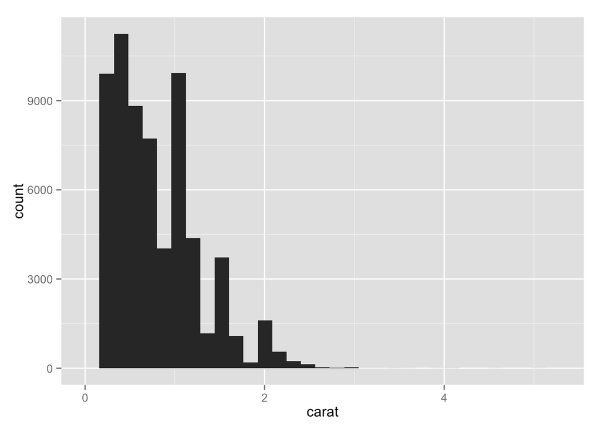

```
##
## > ggplot(data = diamonds) + geom_density(aes(x = carat,
## +     fill = "gray50"))
```

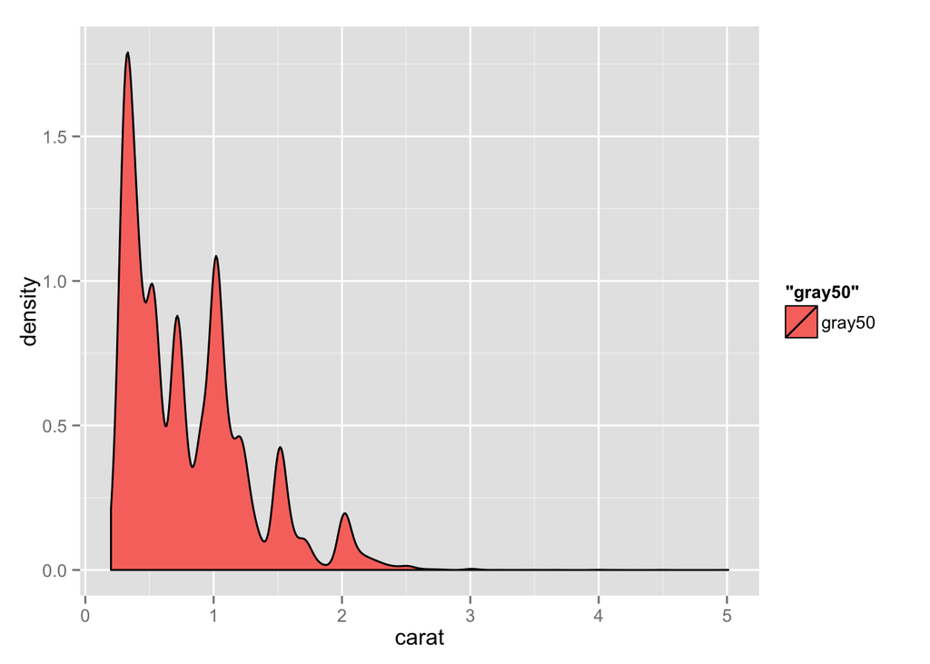

```
##
## > ggplot(diamonds, aes(x = carat, y = price)) + geom_point()
```

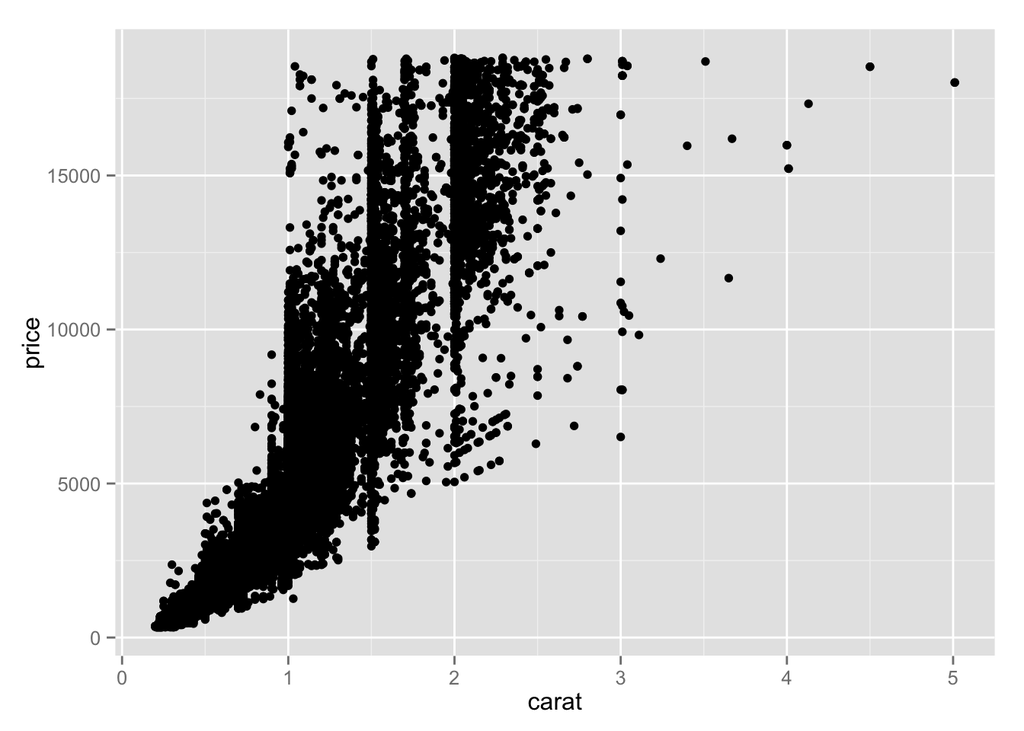

```
##
## > ggplot(subset(diamonds, NAME == "ZALE CORP" | NAME ==
## +     "TIFFANY CO"), aes(x = NAME, y = price)) + geom_point()
```

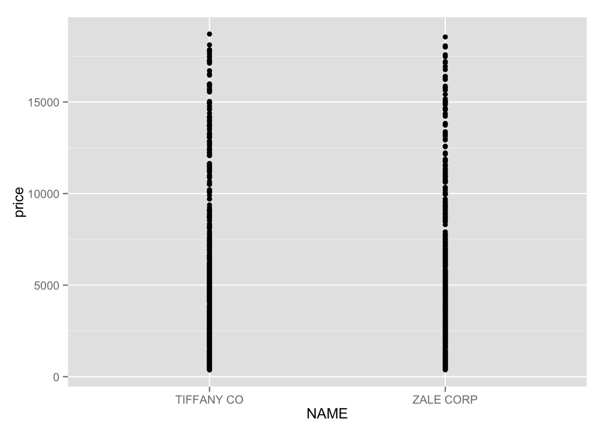

```
##
## > ggplot(subset(diamonds, year(SALES_DATE) == "2009"),
## +     aes(x = paste(year(SALES_DATE), month(SALES_DATE), sep = "-"),
## +         y = price)) +  .... [TRUNCATED]
```

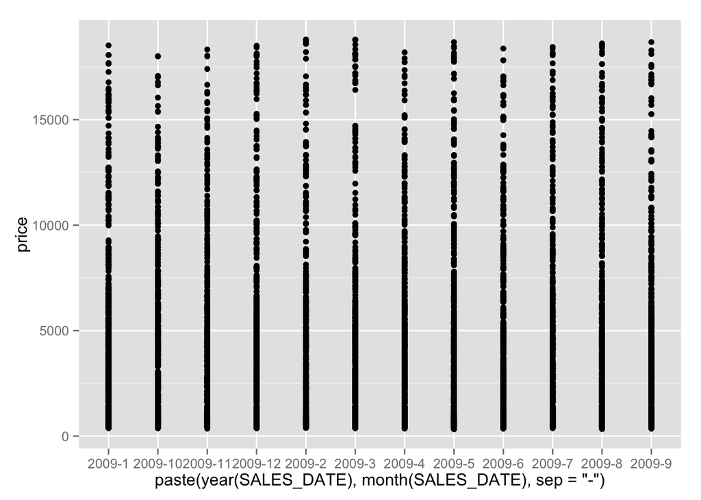

### shiny

**The shiny R package allows you to build interactive web-based applications using only R with no knowledge of html, css, or javascript needed. You just need to write two scripts (see the example files in the 04Shiny directory):**

- ui.R : Defines the layout and the interactive elements that the user can access.
- server.R : Defines what computations are done in response to user interactions.

See also http://shiny.rstudio.com and http://shiny.rstudio.com/tutorial

To run the shiny app that’s in the 04Shiny directory run the following in the main RWorkshop directory (make sure the working directory is set to this directory):  
library(shiny)  
runApp(“04Shiny”) # Make sure there are no spaces in the string argument to runAPP

This should pop the application up in a browser, you can also access it in a browser at http://127.0.0.1:6837.

### shinyapps

The example above ran the shiny app on your local machine, but to share with others, you have to send around the R files and the user needs to have R and know a little bit about it.

Instead, you can remotely host shiny apps and then just send people links. Get a free account at shinyapps.io/signup.html and give it a try.

library(“devtools”, lib.loc=“/Library/Frameworks/R.framework/Versions/3.1/Resources/library”)  
install_github( repo = “shinyapps”, username=“rstudio” )  
shinyapps::setAccountInfo(name=‘pcannata’, token=‘3ECF447A741004F6A8B7208C9ED778E1’, secret=‘. . .’)

**Now you can try the app at https://pcannata.shinyapps.io/04Shiny/**

See also https://www.shinyapps.io/ and http://shiny.rstudio.com/articles/shinyapps.html